# Covid Tracker

```r
setwd('~/Documents/work/data work/')
require(tidyverse)
```

```r
jsonlite::fromJSON('https://api.covid19india.org/raw_data.json', simplifyVector = T)  %>%
  .[[1]] %>%
  as_tibble() %>%
  mutate(Date=as.Date(dateannounced, '%d/%m/%Y')) ->
  covidindia
```

```r
covidindia %>%
  filter(!is.na(Date)) %>%
  count()
```

| n |
| --- |
| 27891 |

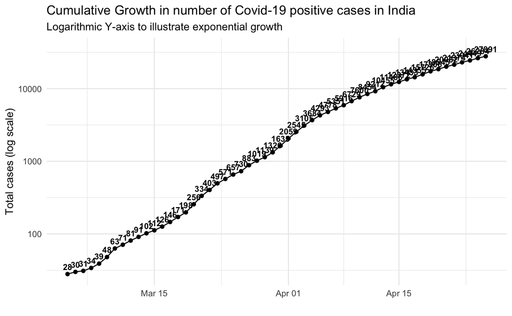

```r
covidindia %>%
  count(Date) %>%
  arrange(Date) %>%
  mutate(Cumul=cumsum(n)) %>%
  filter(Cumul > 20) %>%
  ggplot(aes(x=Date, y=Cumul)) + geom_point() + geom_line() + scale_y_log10("Total cases (log scale)") + geom_text(aes(label=Cumul), nudge_y=0.1, size=3, fontface='bold') + xlab("") + ggtitle("Cumulative Growth in number of Covid-19 positive cases in India", subtitle="Logarithmic Y-axis to illustrate exponential growth") + theme_minimal()
```

Show it instead in terms of doublign time

Smooth better using a 3-day CDGR

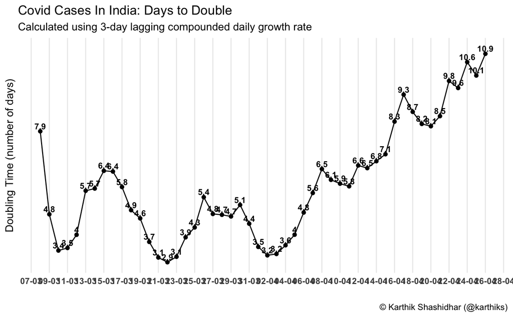

```r
covidindia %>%
  count(Date) %>%
  filter(!is.na(Date)) %>%
  arrange(Date) %>%
  mutate(Cumul=cumsum(n)) %>%
  filter(Cumul >= 30) %>%
  mutate(
    Growth3=log(Cumul/lag(Cumul,3)),
    DoublingTime3=log(2)/Growth3*3
  ) %>%
  filter(!is.na(DoublingTime3)  & Date < Sys.Date()) %>%
  ggplot(aes(x=Date, y=DoublingTime3)) + geom_point() + geom_line()  + scale_y_continuous("Doubling Time (number of days)", breaks=c()) + theme_minimal() + geom_text(aes(label=round(DoublingTime3,1)), nudge_y=0.2, fontface='bold', size=3) + labs(title="Covid Cases In India: Days to Double", subtitle = "Calculated using 3-day lagging compounded daily growth rate", caption="© Karthik Shashidhar (@karthiks)") + scale_x_date('',date_breaks = '2 days', date_labels = '%d-%m') + theme(panel.grid.minor = element_blank(), axis.text = element_text(face='bold'))
```

Let’s plot the growth rate as well

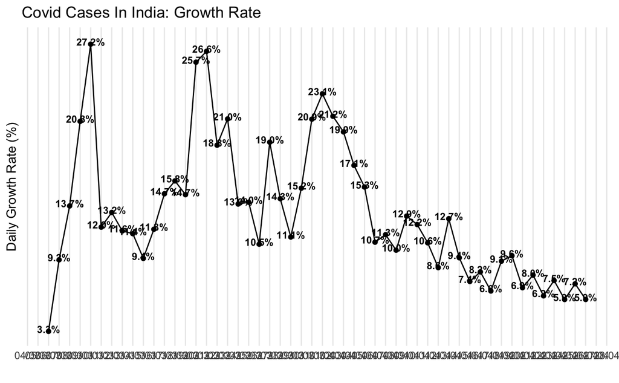

```r
covidindia %>%
  count(Date) %>%
  filter(!is.na(Date)) %>%
  arrange(Date) %>%
  mutate(Cumul=cumsum(n)) %>%
  filter(Cumul >= 30) %>%
  mutate(
    Growth1=log(Cumul/lag(Cumul,1)),
    Days=log(2)/Growth1
  ) %>%
  filter(!is.na(Growth1) ) %>%
  ggplot(aes(x=Date, y=Growth1)) + geom_point() + geom_line()  + scale_y_continuous("Daily Growth Rate (%)", breaks=c()) + theme_minimal() + geom_text(aes(label=scales::percent(Growth1, .1)), nudge_y=0.002, fontface='bold', size=3) + ggtitle("Covid Cases In India: Growth Rate") + scale_x_date('',date_breaks = '1 day', date_labels = '%d/%m') + theme(panel.grid.minor = element_blank())
```

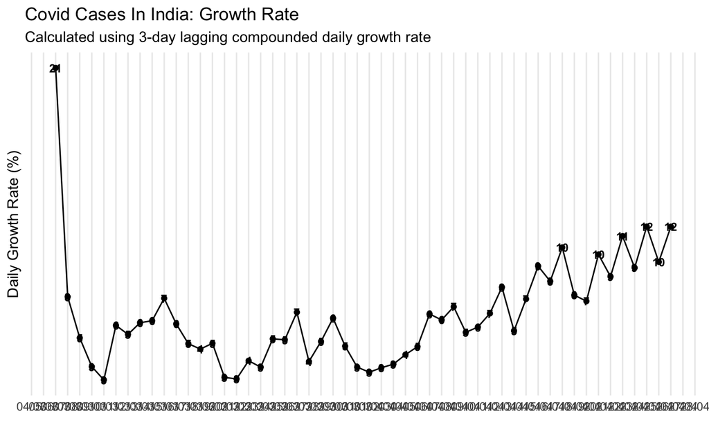

```r
covidindia %>%
  count(Date) %>%
  filter(!is.na(Date)) %>%
  arrange(Date) %>%
  mutate(Cumul=cumsum(n)) %>%
  filter(Cumul >= 30) %>%
  mutate(
    Growth1=log(Cumul/lag(Cumul,1)),
    Days=log(2)/Growth1
  ) %>%
  filter(!is.na(Growth1)  & Date < Sys.Date()) %>%
  ggplot(aes(x=Date, y=Days)) + geom_point() + geom_line()  + scale_y_continuous("Daily Growth Rate (%)", breaks=c()) + theme_minimal() + geom_text(aes(label=round(Days, .1)), nudge_y=0.002, fontface='bold', size=3) + ggtitle("Covid Cases In India: Growth Rate", subtitle = "Calculated using 3-day lagging compounded daily growth rate") + scale_x_date('',date_breaks = '1 day', date_labels = '%d/%m') + theme(panel.grid.minor = element_blank())
```

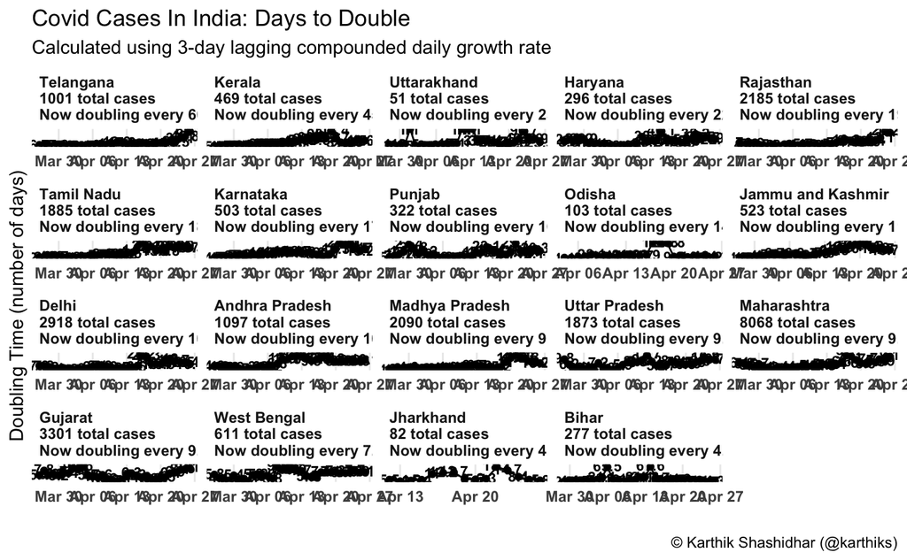

```r
covidindia %>%
  filter(!is.na(Date)) %>%
  rename(State=detectedstate) %>%
  count(Date, State) %>%
  complete(Date, State, fill=list(n=0)) %>%
  group_by(State) %>%
  arrange(Date) %>%
  mutate(Cumul=cumsum(n),Total=sum(n)) %>%
  filter(Cumul >= 5 & Total >= 50) %>%  # ignore small states or states without much data
  mutate(
    Growth3=log(Cumul/lag(Cumul,3)),
    DoublingTime3=log(2)/Growth3*3,
    LastGrowth=Growth3[Date==max(Date)],
    LastDouble=DoublingTime3[Date==max(Date)]
  ) %>%
  filter(!is.na(DoublingTime3) & Date >= as.Date('2020-03-26')) %>%
  mutate(StateCase=paste(State, paste(Total, 'total cases'), paste("Now doubling every", round(LastDouble, 1), "days"),  sep='\n')) %>%
  ggplot(aes(x=Date, y=DoublingTime3)) + geom_point() + geom_line()  + scale_y_continuous("Doubling Time (number of days)", breaks=c()) + theme_minimal() + geom_text(aes(label=round(DoublingTime3,1), y=1.1*DoublingTime3), fontface='bold', size=3) + labs(title="Covid Cases In India: Days to Double", subtitle = "Calculated using 3-day lagging compounded daily growth rate", caption="© Karthik Shashidhar (@karthiks)" ) + scale_x_date('') + facet_wrap(~reorder(StateCase, LastGrowth), scales='free') + theme(strip.text = element_text(face='bold', hjust=0), panel.grid.minor = element_blank(), axis.text = element_text(face='bold'))
```

Let’s do this by district

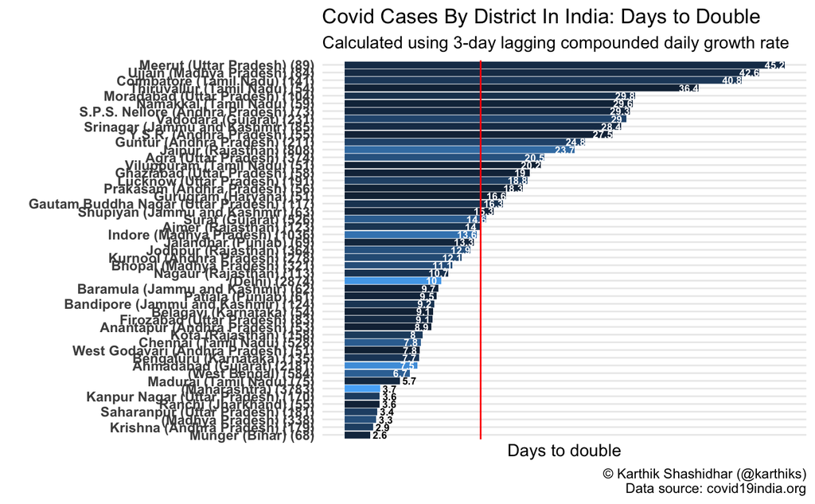

```r
covidindia %>%
  filter(!is.na(Date)) %>%
  mutate(State=paste0(detecteddistrict, ' (', detectedstate, ')')) %>%
  count(Date, State) %>%
  complete(Date, State, fill=list(n=0)) %>%
  group_by(State) %>%
  arrange(Date) %>%
  mutate(Cumul=cumsum(n),Total=sum(n)) %>%
  filter(Cumul >= 5 & Total >= 50) %>%  # ignore small states or states without much data
  mutate(
    Growth3=log(Cumul/lag(Cumul,3)),
    DoublingTime3=log(2)/Growth3*3,
    LastGrowth=Growth3[Date==max(Date)],
    LastDouble=DoublingTime3[Date==max(Date)]
  ) %>%
  filter(!is.na(DoublingTime3) & Date==max(Date) & DoublingTime3 < 50) %>%
  mutate(StateCase=paste0(State, ' (',Total, ')'))%>%
  ggplot(aes(x=reorder(StateCase, LastDouble), y=LastDouble, fill=log(Total), label=round(LastDouble, 1))) + geom_col() + geom_text(size=2.3, aes(y=ifelse(LastDouble < 6, LastDouble + 1, LastDouble - 1), col=ifelse(LastDouble < 6, 'black', 'white')), fontface='bold') + scale_y_continuous("Days to double", breaks=c()) + theme_minimal() + labs(title="Covid Cases By District In India: Days to Double", subtitle = "Calculated using 3-day lagging compounded daily growth rate", caption="© Karthik Shashidhar (@karthiks)\n Data source: covid19india.org" ) + xlab('') + coord_flip() + theme(panel.grid.minor = element_blank(), axis.text = element_text(face='bold'), legend.position = 'none') + scale_fill_gradient() + scale_colour_identity() + geom_hline(yintercept = 14, col='red', lwd=0.5)
```

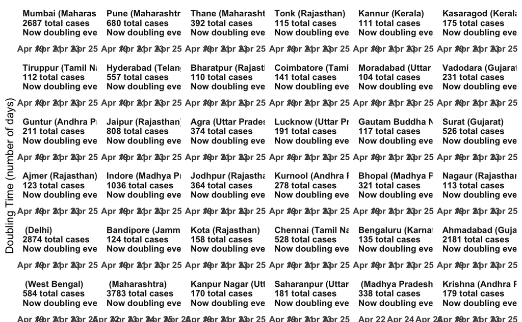

```r
covidindia %>%
  filter(!is.na(Date)) %>%
  mutate(State=paste0(detecteddistrict, ' (', detectedstate, ')')) %>%
  count(Date, State) %>%
  complete(Date, State, fill=list(n=0)) %>%
  group_by(State) %>%
  arrange(Date) %>%
  mutate(Cumul=cumsum(n),Total=sum(n)) %>%
  filter(Cumul >= 5 & Total >= 100) %>%  # ignore small states or states without much data
  mutate(
    Growth3=log(Cumul/lag(Cumul,3)),
    DoublingTime3=log(2)/Growth3*3,
    LastGrowth=Growth3[Date==max(Date)],
    LastDouble=DoublingTime3[Date==max(Date)]
  ) %>%
  filter(!is.na(DoublingTime3) & Date >= Sys.Date() - 10) %>%
  mutate(StateCase=paste(State, paste(Total, 'total cases'), paste("Now doubling every", round(LastDouble, 1), "days"),  sep='\n')) %>%
  ggplot(aes(x=Date, y=DoublingTime3)) + geom_point() + geom_line()  + scale_y_continuous("Doubling Time (number of days)", breaks=c()) + theme_minimal() + geom_text(aes(label=round(DoublingTime3,1), y=1.1*DoublingTime3), fontface='bold', size=3) + labs(title="Covid Cases In India: Days to Double", subtitle = "Calculated using 3-day lagging compounded daily growth rate", caption="© Karthik Shashidhar (@karthiks)" ) + scale_x_date('') + facet_wrap(~reorder(StateCase, LastGrowth), scales='free') + theme(strip.text = element_text(face='bold', hjust=0), panel.grid.minor = element_blank(), axis.text = element_text(face='bold'))
```

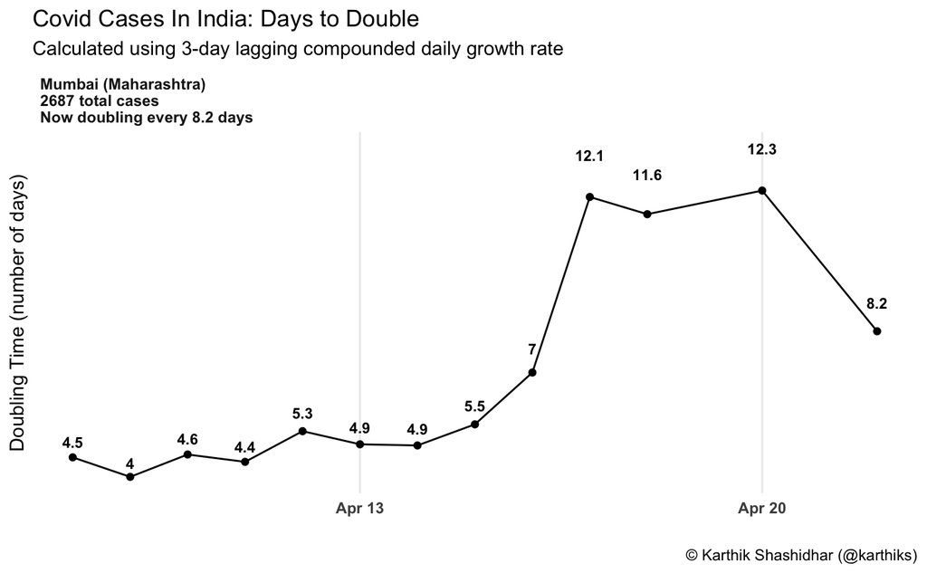

```r
covidindia %>%
  filter(!is.na(Date) & detecteddistrict=='Mumbai') %>%
  mutate(State=paste0(detecteddistrict, ' (', detectedstate, ')')) %>%
  count(Date, State) %>%
  complete(Date, State, fill=list(n=0)) %>%
  group_by(State) %>%
  arrange(Date) %>%
  mutate(Cumul=cumsum(n),Total=sum(n)) %>%
  mutate(
    Growth3=log(Cumul/lag(Cumul,3)),
    DoublingTime3=log(2)/Growth3*3,
    LastGrowth=Growth3[Date==max(Date)],
    LastDouble=DoublingTime3[Date==max(Date)]
  ) %>%
  filter(!is.na(DoublingTime3) & Date >= Sys.Date() - 20) %>%
  mutate(StateCase=paste(State, paste(Total, 'total cases'), paste("Now doubling every", round(LastDouble, 1), "days"),  sep='\n')) %>%
  ggplot(aes(x=Date, y=DoublingTime3)) + geom_point() + geom_line()  + scale_y_continuous("Doubling Time (number of days)", breaks=c()) + theme_minimal() + geom_text(aes(label=round(DoublingTime3,1), y=1.1*DoublingTime3), fontface='bold', size=3) + labs(title="Covid Cases In India: Days to Double", subtitle = "Calculated using 3-day lagging compounded daily growth rate", caption="© Karthik Shashidhar (@karthiks)" ) + scale_x_date('') + facet_wrap(~reorder(StateCase, LastGrowth), scales='free') + theme(strip.text = element_text(face='bold', hjust=0), panel.grid.minor = element_blank(), axis.text = element_text(face='bold'))
```

Do the bar graph only for Karnataka

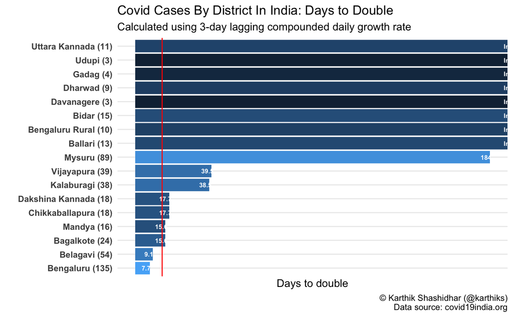

```r
covidindia %>%
  filter(!is.na(Date) & detectedstate=='Karnataka') %>%
  mutate(State=detecteddistrict) %>%
  count(Date, State) %>%
  complete(Date, State, fill=list(n=0)) %>%
  group_by(State) %>%
  arrange(Date) %>%
  mutate(Cumul=cumsum(n),Total=sum(n)) %>%
  filter(Cumul >= 3 & Total >= 3) %>%  # ignore small states or states without much data
  mutate(
    Growth3=log(Cumul/lag(Cumul,3)),
    DoublingTime3=log(2)/Growth3*3,
    LastGrowth=Growth3[Date==max(Date)],
    LastDouble=DoublingTime3[Date==max(Date)]
  ) %>%
  filter(!is.na(DoublingTime3) & Date==max(Date)) %>%
  mutate(StateCase=paste0(State, ' (',Total, ')'))%>%
  ggplot(aes(x=reorder(StateCase, LastDouble), y=LastDouble, fill=log(Total), label=round(LastDouble, 1))) + geom_col() + geom_text(size=2.3, aes(y=ifelse(LastDouble < 6, LastDouble + 2, LastDouble - 2), col=ifelse(LastDouble < 6, 'black', 'white')), fontface='bold') + scale_y_continuous("Days to double", breaks=c()) + theme_minimal() + labs(title="Covid Cases By District In India: Days to Double", subtitle = "Calculated using 3-day lagging compounded daily growth rate", caption="© Karthik Shashidhar (@karthiks)\n Data source: covid19india.org" ) + xlab('') + coord_flip() + theme(panel.grid.minor = element_blank(), axis.text = element_text(face='bold'), legend.position = 'none') + scale_fill_gradient() + scale_colour_identity() + geom_hline(yintercept = 14, col='red', lwd=0.5)
```

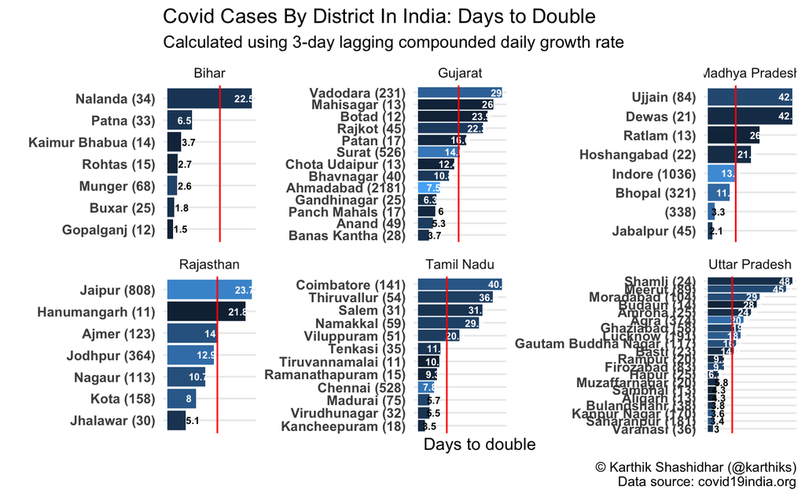

```r
covidindia %>%
  filter(!is.na(Date) & detectedstate %in% c('Uttar Pradesh',"Bihar", "Tamil Nadu", "Gujarat", "Rajasthan", "Madhya Pradesh")) %>%
  mutate(District=detecteddistrict, State=detectedstate) %>%
  count(Date, State, District) %>%
  group_by(State) %>%
  complete(Date, District, fill=list(n=0)) %>%
  group_by(State, District) %>%
  arrange(Date) %>%
  mutate(Cumul=cumsum(n),Total=sum(n)) %>%
  filter(Cumul >= 3 & Total >= 10) %>%  # ignore small states or states without much data
  mutate(
    Growth3=log(Cumul/lag(Cumul,3)),
    DoublingTime3=log(2)/Growth3*3,
    LastGrowth=Growth3[Date==max(Date)],
    LastDouble=DoublingTime3[Date==max(Date)]
  ) %>%
  filter(!is.na(DoublingTime3) & Date==max(Date) & DoublingTime3 <= 50) %>%
  mutate(StateCase=paste0(District, ' (',Total, ')'))%>%
  ggplot(aes(x=reorder(StateCase, LastDouble), y=LastDouble, fill=log(Total), label=round(LastDouble, 1))) + geom_col() + geom_text(size=2.3, aes(y=ifelse(LastDouble < 6, LastDouble + 2, LastDouble - 2), col=ifelse(LastDouble < 6, 'black', 'white')), fontface='bold') + scale_y_continuous("Days to double", breaks=c()) + theme_minimal() + labs(title="Covid Cases By District In India: Days to Double", subtitle = "Calculated using 3-day lagging compounded daily growth rate", caption="© Karthik Shashidhar (@karthiks)\n Data source: covid19india.org" ) + xlab('') + coord_flip() + theme(panel.grid.minor = element_blank(), axis.text = element_text(face='bold'), legend.position = 'none') + scale_fill_gradient() + scale_colour_identity() + facet_wrap(~State, scales='free') + geom_hline(yintercept = 14, col='red', lwd=0.5)
```

Only for Karnataka

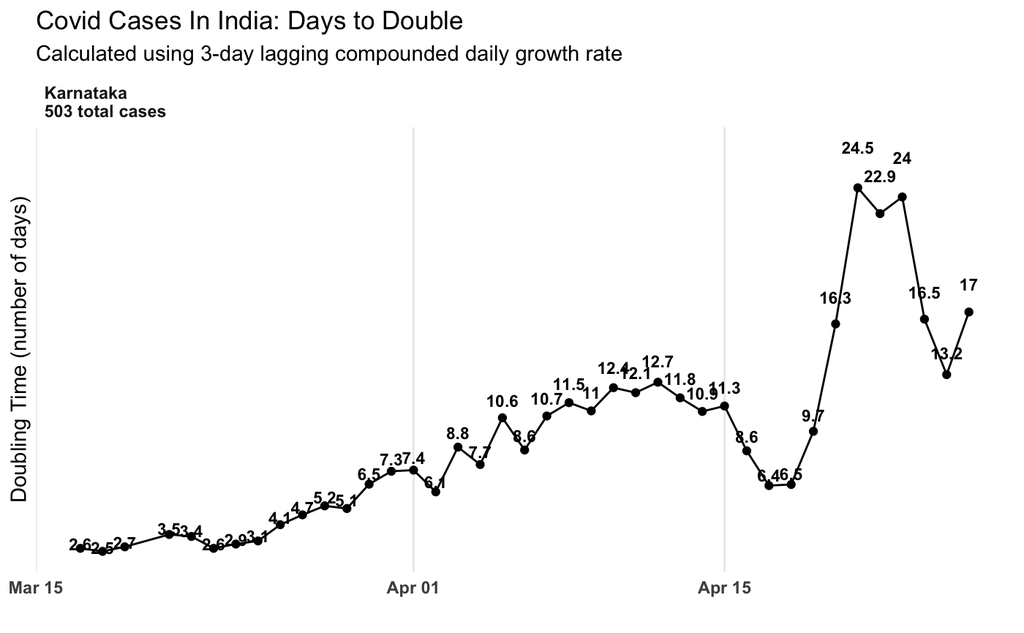

```r
covidindia %>%
  filter(!is.na(Date)) %>%
  rename(State=detectedstate) %>%
  filter(State=="Karnataka") %>%
  count(Date, State) %>%
  complete(Date, State, fill=list(n=0)) %>%
  group_by(State) %>%
  arrange(Date) %>%
  mutate(Cumul=cumsum(n),Total=sum(n)) %>%
  filter(Cumul >= 5 & Total >= 50) %>%  # ignore small states or states without much data
  mutate(
    Growth3=log(Cumul/lag(Cumul,3)),
    DoublingTime3=log(2)/Growth3*3,
    LastGrowth=Growth3[Date==max(Date)]
  ) %>%
  filter(!is.na(DoublingTime3) ) %>%
  mutate(StateCase=paste(State, paste(Total, 'total cases'), sep='\n')) %>%
  ggplot(aes(x=Date, y=DoublingTime3)) + geom_point() + geom_line()  + scale_y_continuous("Doubling Time (number of days)", breaks=c()) + theme_minimal() + geom_text(aes(label=round(DoublingTime3,1), y=1.1*DoublingTime3), fontface='bold', size=3) + ggtitle("Covid Cases In India: Days to Double", subtitle = "Calculated using 3-day lagging compounded daily growth rate") + scale_x_date('') + facet_wrap(~reorder(StateCase, LastGrowth), scales='free') + theme(strip.text = element_text(face='bold', hjust=0), panel.grid.minor = element_blank(), axis.text = element_text(face='bold'))
```

State wise absolute

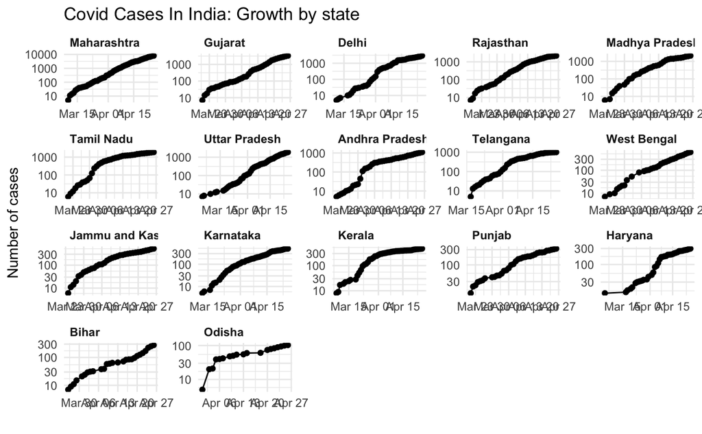

```r
covidindia %>%
  rename(State=detectedstate) %>%
  count(Date, State) %>%
  filter(!is.na(Date)) %>%
  group_by(State) %>%
  arrange(Date) %>%
  mutate(Cumul=cumsum(n),Total=sum(n)) %>%
  filter(Cumul >= 5 & Total >= 100) %>% # ignore small states or states without much data
  ggplot(aes(x=Date, y=Cumul)) + geom_point() + geom_line() + scale_y_log10("Number of cases") + theme_minimal() + facet_wrap(~reorder(State, -Total), scales='free') + ggtitle("Covid Cases In India: Growth by state") + scale_x_date('')  + theme(strip.text = element_text(face='bold', hjust=0))
```

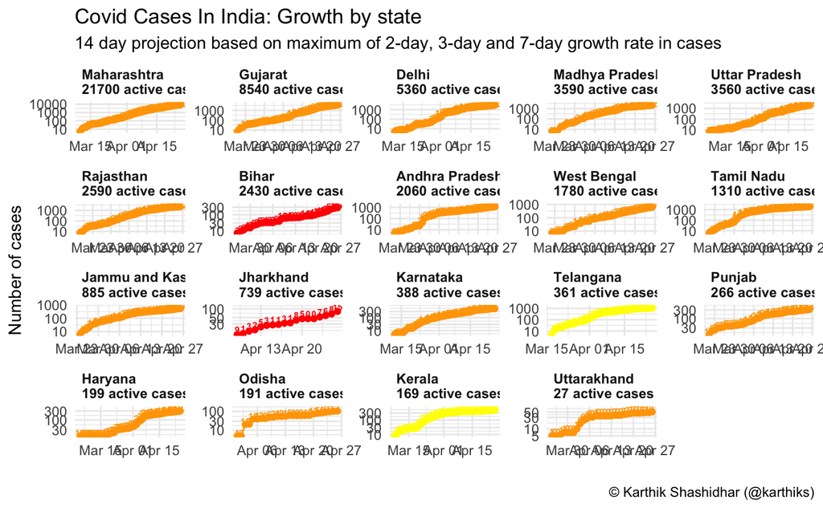

```r
covidindia %>%
  rename(State=detectedstate) %>%
  filter(!is.na(Date) & Date < Sys.Date()) %>%
  count(Date, State) %>%
  complete(Date, State, fill=list(n=0)) %>%
  filter(!is.na(Date)) %>%
  group_by(State) %>%
  arrange(Date) %>%
  mutate(
    Cumul=cumsum(n),
    Today=sum(n),
    Lag7=Cumul[Date==(max(Date)-7)],
    Growth7=log(Today/Lag7)/7,
    Lag3=Cumul[Date==(max(Date)-3)],
    Growth3=log(Today/Lag3)/3,
    Lag2=Cumul[Date==(max(Date)-2)],
    Growth2=log(Today/Lag2)/2,
    GrowthRate=pmax(Growth7, Growth3, Growth2),
    Forecast2weeks=Today*exp(14*GrowthRate)  - Today,  # People infected until today would have bee cured in 2 weeks' time,
    Colour=ifelse(GrowthRate <= log(2)/30, 'yellow', ifelse(GrowthRate <= log(2)/7, 'orange', 'red'))
  ) %>%
  ungroup() %>%
  mutate(StateLabel=paste(State, paste(signif(round(Forecast2weeks),3), 'active cases on', format(Sys.Date()+14, '%d-%b')), sep='\n')) %>%
  filter(Cumul >= 5 & Today >= 50) ->  # ignore small states or states without much data
  stateCumul
stateCumul %>%
  ggplot(aes(x=Date, y=Cumul, col=Colour)) + geom_point() + geom_line() + scale_y_log10("Number of cases") + theme_minimal() + geom_text(aes(label=n, y=1.5*Cumul), fontface='bold', size=2) + facet_wrap(~reorder(StateLabel, -Forecast2weeks), scales='free') + labs(title="Covid Cases In India: Growth by state", subtitle="14 day projection based on maximum of 2-day, 3-day and 7-day growth rate in cases", caption="© Karthik Shashidhar (@karthiks)") + scale_x_date('')  + theme(strip.text = element_text(face='bold', hjust=0)) + scale_colour_identity()
```

The above graph was misleading. Let me change it up so that we now have active cases per day, assuming a recovery period of 14 days, and a growth equal to max of 2, 3, 7 day growth

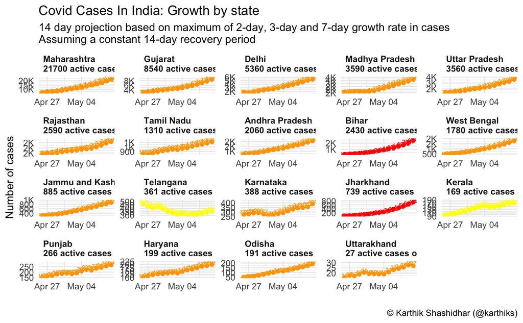

```r
covidindia %>%
  rename(State=detectedstate) %>%
  filter(!is.na(Date) & Date < Sys.Date() & State != '') %>%
  count(Date, State) %>%
  complete(Date, State, fill=list(n=0)) %>%
  filter(!is.na(Date)) %>%
  group_by(State) %>%
  arrange(Date) %>%
  mutate(
    Cumul=cumsum(n),
    Today=sum(n),
    Lag7=Cumul[Date==(max(Date)-7)],
    Growth7=log(Today/Lag7)/7,
    Lag3=Cumul[Date==(max(Date)-3)],
    Growth3=log(Today/Lag3)/3,
    Lag2=Cumul[Date==(max(Date)-2)],
    Growth2=log(Today/Lag2)/2,
    GrowthRate=pmax(Growth7, Growth3, Growth2),
    Colour=ifelse(GrowthRate <= log(2)/30, 'yellow', ifelse(GrowthRate <= log(2)/7, 'orange', 'red'))
  ) %>%
  select(Date, State, Cumul, GrowthRate, Colour, Today) %>%
  inner_join(
    (.) %>%
      filter(Date==max(Date)) %>%
      select(Date, State, Today, GrowthRate) %>%
      crossing(Projection=0:14) %>%
      mutate(
        ProjectedDate=Date + Projection,
        ProjectedCases=Today * exp(Projection * GrowthRate),
        Date=ProjectedDate-14
      ) %>%
      select(-GrowthRate, -Today, -Projection),
    by=c("State", "Date")
  ) %>%
  mutate(
    LiveCases=ProjectedCases-Cumul,
    StateLabel=paste(State, paste(signif(round(Today*exp(14*GrowthRate)-Today),3), 'active cases on', format(Sys.Date()+14, '%d-%b')), sep='\n')
    ) %>%
  filter(Cumul >= 5 & Today >= 50) %>%
  ggplot(aes(x=ProjectedDate, y=LiveCases, col=Colour)) + geom_point() + geom_line() + scale_y_continuous("Number of cases", labels=scales::label_number_si()) + theme_minimal() + geom_text(aes(label=round(LiveCases), y=1.1*LiveCases), fontface='bold', size=2) + facet_wrap(~reorder(StateLabel, -Today*exp(GrowthRate*14)), scales='free') + labs(title="Covid Cases In India: Growth by state", subtitle="14 day projection based on maximum of 2-day, 3-day and 7-day growth rate in cases\nAssuming a constant 14-day recovery period", caption="© Karthik Shashidhar (@karthiks)") + scale_x_date('')  + theme(strip.text = element_text(face='bold', hjust=0)) + scale_colour_identity()
```

```r
NA
```

Plot on linear scale to see rate of growth properly

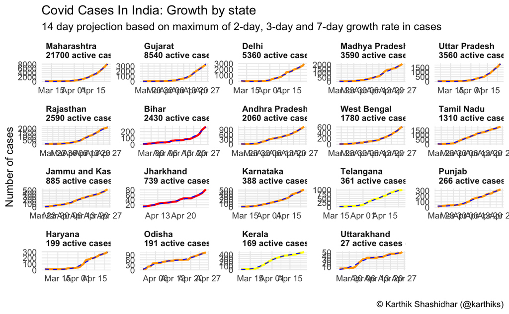

```r
stateCumul %>%
  ggplot(aes(x=Date, y=Cumul, col=Colour)) + geom_line(lwd=1) + geom_smooth(se=F, col='blue', lwd=0.5, lty=2) + scale_y_continuous("Number of cases") + theme_minimal() +  facet_wrap(~reorder(StateLabel, -Forecast2weeks), scales='free') + labs(title="Covid Cases In India: Growth by state", subtitle="14 day projection based on maximum of 2-day, 3-day and 7-day growth rate in cases", caption="© Karthik Shashidhar (@karthiks)") + scale_x_date('')  + theme(strip.text = element_text(face='bold', hjust=0)) + scale_colour_identity()
```

```r
log(1.5)/7
```

```
[1] 0.05792359
```

Same thing by districts of Karnataka

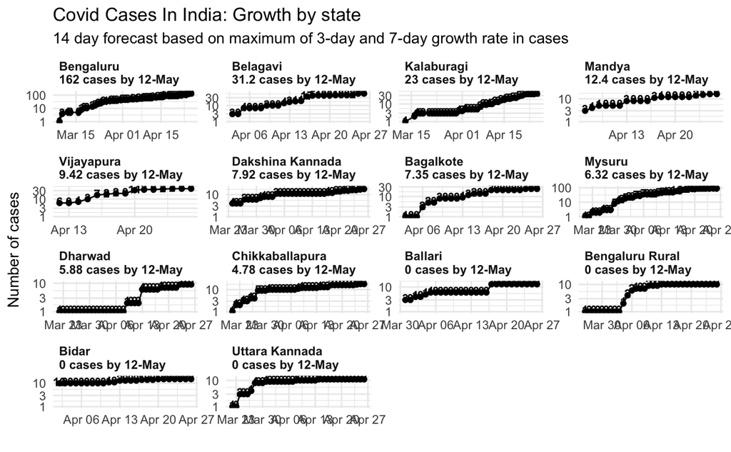

```r
covidindia %>%
  rename(State=detectedstate, District=detecteddistrict) %>%
  filter(State=='Karnataka') %>%
  count(Date, District) %>%
  complete(Date, District, fill=list(n=0)) %>%
  filter(!is.na(Date)) %>%
  group_by(District) %>%
  arrange(Date) %>%
  mutate(
    Cumul=cumsum(n),
    Today=sum(n),
    Lag7=Cumul[Date==(Sys.Date()-7)],
    Growth7=ifelse(Lag7 > 0, log(Today/Lag7)/7, 0),
    Lag3=Cumul[Date==(Sys.Date()-3)],
    Growth3=ifelse(Lag3 > 0, log(Today/Lag3)/3, 0),
    Lag2=Cumul[Date==(Sys.Date()-2)],
    Growth2=ifelse(Lag2 > 0, log(Today/Lag2)/2, 0),
    GrowthRate=pmax(Growth7, Growth3, Growth2),
    Forecast2weeks=Today*exp(14*GrowthRate) - Today  # People infected until today would have bee cured in 2 weeks' time
  ) %>%
  ungroup() %>%
  mutate(District=paste(District, paste(signif(Forecast2weeks,3), 'cases by', format(Sys.Date()+14, '%d-%b')), sep='\n')) %>%
  filter(Today >= 7 & Cumul > 0) %>%
  ggplot(aes(x=Date, y=Cumul)) + geom_point() + geom_line() + scale_y_log10("Number of cases", lim=c(1, NA)) + theme_minimal() + geom_text(aes(label=n, y=1.2*Cumul), fontface='bold', size=3) + facet_wrap(~reorder(District, -Forecast2weeks), scales='free') + ggtitle("Covid Cases In India: Growth by state", subtitle="14 day forecast based on maximum of 3-day and 7-day growth rate in cases") + scale_x_date('')  + theme(strip.text = element_text(face='bold', hjust=0))
```

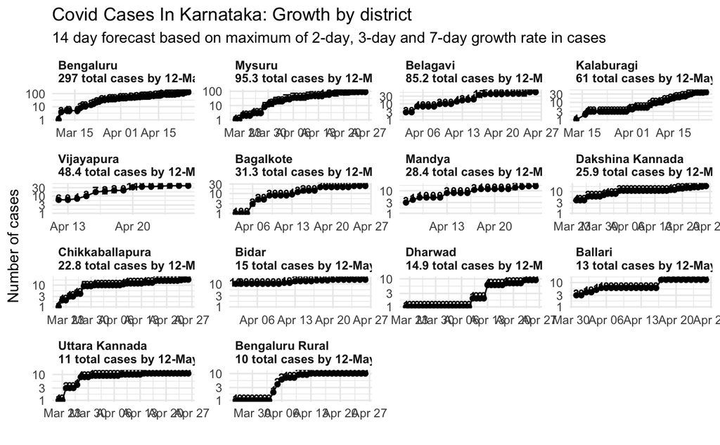

```r
covidindia %>%
  rename(State=detectedstate, District=detecteddistrict) %>%
  filter(State=='Karnataka') %>%
  count(Date, District) %>%
  complete(Date, District, fill=list(n=0)) %>%
  filter(!is.na(Date)) %>%
  group_by(District) %>%
  arrange(Date) %>%
  mutate(
    Cumul=cumsum(n),
    Today=sum(n),
    Lag7=Cumul[Date==(Sys.Date()-7)],
    Growth7=ifelse(Lag7 > 0, log(Today/Lag7)/7, 0),
    Lag3=Cumul[Date==(Sys.Date()-3)],
    Growth3=ifelse(Lag3 > 0, log(Today/Lag3)/3, 0),
    Lag2=Cumul[Date==(Sys.Date()-2)],
    Growth2=ifelse(Lag2 > 0, log(Today/Lag2)/2, 0),
    GrowthRate=pmax(Growth7, Growth3, Growth2),
    Forecast2weeks=Today*exp(14*GrowthRate) # People infected until today would have bee cured in 2 weeks' time
  ) %>%
  ungroup() %>%
  mutate(District=paste(District, paste(signif(Forecast2weeks,3), 'total cases by', format(Sys.Date()+14, '%d-%b')), sep='\n')) %>%
  filter(Today >= 7 & Cumul > 0) %>%
  ggplot(aes(x=Date, y=Cumul)) + geom_point() + geom_line() + scale_y_log10("Number of cases", lim=c(1, NA)) + theme_minimal() + geom_text(aes(label=n, y=1.2*Cumul), fontface='bold', size=3) + facet_wrap(~reorder(District, -Forecast2weeks), scales='free') + ggtitle("Covid Cases In Karnataka: Growth by district", subtitle="14 day forecast based on maximum of 2-day, 3-day and 7-day growth rate in cases") + scale_x_date('')  + theme(strip.text = element_text(face='bold', hjust=0))
```

```r
covidindia %>%
  mutate(TJ=contractedfromwhichpatientsuspected=='E0') %>%
  count(typeoftransmission, TJ,  sort=T) %>%
  spread(TJ,n)
```

| typeoftransmission | FALSE | TRUE |
| --- | --- | --- |
|  | 24845 | 56 |
| Imported | 617 | 13 |
| Imported | 2 | NA |
| Local | 832 | 888 |
| TBD | 636 | 1 |
| Unknown | 1 | NA |

```r
covidindia %>%
  filter(str_detect(contractedfromwhichpatientsuspected, 'E0')) %>%
  count(notes, sort=T) %>%
  mutate(notes=str_sub(notes, 1,80)) %>%
  mutate(Cumul=cumsum(n))
```

| notes | n | Cumul |
| --- | --- | --- |
| Travelled to Delhi | 862 | 862 |
| Details awaited | 45 | 907 |
| Indonesian | 7 | 914 |
| Delhi Conference | 6 | 920 |
| Travelled from Delhi | 6 | 926 |
| Travelled from Delhi (Repeat Test) | 5 | 931 |
| Travel history of Delhi | 4 | 935 |
| Contact of Delhi Conference - P134,P135,P136,P137,P138 | 3 | 938 |
| Attended Delhi Conference | 2 | 940 |
| Contact of AP-P10; attended Delhi Conference | 2 | 942 |

[output cut: 13 more lines]

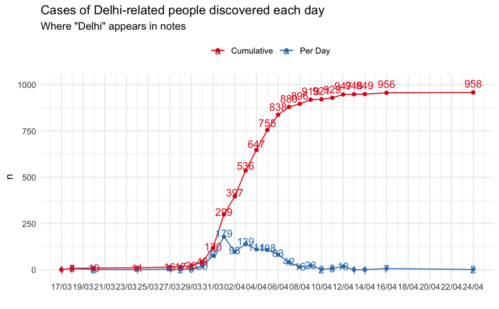

```r
covidindia %>%
  filter(str_detect(contractedfromwhichpatientsuspected, 'E0')) %>%
  count(Date) %>%
  ggplot(aes(x=Date, y=n,col="Per Day")) + geom_point() + geom_line() + ggtitle("Cases of Delhi-related people discovered each day", subtitle='Where "Delhi" appears in notes') + geom_point(aes(y=cumsum(n), col="Cumulative")) + geom_line(aes(y=cumsum(n), col='Cumulative')) + theme_minimal() + scale_color_brewer(palette="Set1") + theme(legend.title = element_blank(), legend.position = 'top') + geom_text(aes(label=n, y=1.1*n)) + geom_text(aes(label=cumsum(n), y=1.05*cumsum(n), col='Cumulative')) + scale_x_date('', date_breaks='2 days',date_labels = '%d/%m')
```

```r
covidindia %>%
  filter(contractedfromwhichpatientsuspected=='E0') %>%
  count(detectedstate, detecteddistrict, sort=T)
```

| detectedstate | detecteddistrict | n |
| --- | --- | --- |
| Tamil Nadu | Chennai | 67 |
| Tamil Nadu | Coimbatore | 57 |
| Tamil Nadu | Dindigul | 45 |
| Tamil Nadu | Tirunelveli | 37 |
| Tamil Nadu | Tiruchirappalli | 30 |
| Uttar Pradesh | Saharanpur | 27 |
| Delhi | South Delhi | 24 |
| Tamil Nadu | Ranipet | 24 |
| Tamil Nadu | Theni | 23 |
| Telangana | Hyderabad | 23 |

[output cut: 124 more lines]

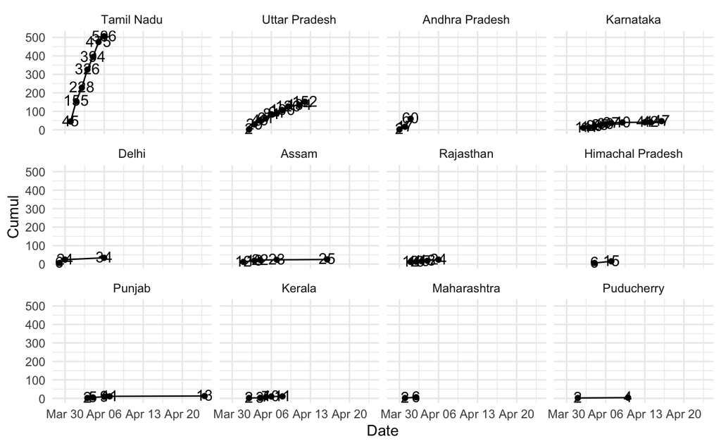

```r
covidindia %>%
  filter(contractedfromwhichpatientsuspected=='E0') %>%
  filter(Date >= as.Date('2020-03-28')) %>%
  count(detectedstate, Date) %>%
  inner_join(
    (.) %>%
      group_by(detectedstate)%>%
      filter(length(unique(Date)) > 1) %>%
      summarise(total=sum(n)) %>%
      arrange(-total) %>%
      head(12),
    by='detectedstate'
  ) %>%
  group_by(detectedstate) %>%
  arrange(Date) %>%
  mutate(Cumul=cumsum(n)) %>%
  ungroup() %>%
  ggplot(aes(x=Date, y=Cumul, label=Cumul)) + geom_line() + geom_point() + geom_text(nudge_y=5) + facet_wrap(~reorder(detectedstate, -total), scales='fixed') + theme_minimal()
```

```r
covidindia %>%
  filter(str_detect(detecteddistrict, 'Indore'))
```

| agebracket | backupnotes | contractedfromwhichpatientsuspected | currentstatus | dateannounced | detectedcity | detecteddistrict | detectedstate | estimatedonsetdate | gender | nationality | notes | patientnumber | source1 | source2 | source3 | statecode | statepatientnumber | statuschangedate | typeoftransmission | Date |
| --- | --- | --- | --- | --- | --- | --- | --- | --- | --- | --- | --- | --- | --- | --- | --- | --- | --- | --- | --- | --- |
|  |  |  | Hospitalized | 25/03/2020 | Indore | Indore | Madhya Pradesh |  |  | India | Details awaited, (family) | 573 | https://twitter.com/PTI_News/status/1242660625228021762 | https://dbpost.com/mp-coronavirus-cases-updates-14-cases-of-covid-19-in-state-4-fresh-cases-in-indore-and-one-in-ujjain/ |  | MP |  | 25/03/2020 | Local | 2020-03-25 |
|  |  | P573 | Hospitalized | 25/03/2020 | Indore | Indore | Madhya Pradesh |  |  | India | Details awaited, (family) | 574 | https://twitter.com/PTI_News/status/1242660625228021762 | https://dbpost.com/mp-coronavirus-cases-updates-14-cases-of-covid-19-in-state-4-fresh-cases-in-indore-and-one-in-ujjain/ |  | MP |  | 25/03/2020 | Local | 2020-03-25 |
|  |  | P573 | Hospitalized | 25/03/2020 | Indore | Indore | Madhya Pradesh |  |  | India | Details awaited, (family) | 575 | https://twitter.com/PTI_News/status/1242660625228021762 | https://dbpost.com/mp-coronavirus-cases-updates-14-cases-of-covid-19-in-state-4-fresh-cases-in-indore-and-one-in-ujjain/ |  | MP |  | 25/03/2020 | Local | 2020-03-25 |
|  |  |  | Hospitalized | 25/03/2020 | Indore | Indore | Madhya Pradesh |  |  | India | Travelled from Rishikesh | 576 | https://twitter.com/PTI_News/status/1242660625228021762 | https://dbpost.com/mp-coronavirus-cases-updates-14-cases-of-covid-19-in-state-4-fresh-cases-in-indore-and-one-in-ujjain/ |  | MP |  | 25/03/2020 | TBD | 2020-03-25 |
|  |  |  | Hospitalized | 26/03/2020 | Indore | Indore | Madhya Pradesh |  |  |  | Details Awaited | 661 | https://twitter.com/PTI_News/status/1243039656540692482 |  |  | MP |  | 26/03/2020 | TBD | 2020-03-26 |
|  |  |  | Hospitalized | 26/03/2020 | Indore | Indore | Madhya Pradesh |  |  |  | Details Awaited | 662 | https://twitter.com/PTI_News/status/1243039656540692482 |  |  | MP |  | 26/03/2020 | TBD | 2020-03-26 |
|  |  |  | Hospitalized | 26/03/2020 | Indore | Indore | Madhya Pradesh |  |  |  | Details Awaited | 663 | https://twitter.com/PTI_News/status/1243039656540692482 |  |  | MP |  | 26/03/2020 | TBD | 2020-03-26 |
|  |  |  | Hospitalized | 26/03/2020 | Indore | Indore | Madhya Pradesh |  |  |  | Details Awaited | 664 | https://twitter.com/PTI_News/status/1243039656540692482 |  |  | MP |  | 26/03/2020 | TBD | 2020-03-26 |
|  |  |  | Hospitalized | 26/03/2020 | Indore | Indore | Madhya Pradesh |  |  |  | Details Awaited | 665 | https://twitter.com/PTI_News/status/1243039656540692482 |  |  | MP |  | 26/03/2020 | TBD | 2020-03-26 |
| 35 |  |  | Deceased | 27/03/2020 |  | Indore | Madhya Pradesh |  | M |  | Details awaited | 747 | https://www.indiatoday.in/india/story/madhya-pradesh-second-coronavirus-death-man-indore-covid19-1660040-2020-03-26 |  |  | MP |  | 27/03/2020 | TBD | 2020-03-27 |

[output cut: 990 more lines]

```r
covidindia %>%
  filter(detectedstate=='Karnataka') %>%
  select(Date, StateID=statepatientnumber, City=detectedcity, District=detecteddistrict,Status=currentstatus, Notes=notes, Age=agebracket, Sex=gender, Transmission=typeoftransmission, MoreNotes=backupnotes) %>%
  mutate(Notes=str_sub(Notes, 1, 60)) %>%
  arrange(desc(Date), District, desc(StateID))
```

| Date | StateID | City | District | Status | Notes | Age | Sex | Transmission | MoreNotes |
| --- | --- | --- | --- | --- | --- | --- | --- | --- | --- |
| 2020-04-26 | KA-P501 | Panemangalore | Dakshina Kannada | Hospitalized | Contact of KA-P432 | 47 | F |  |  |
| 2020-04-26 | KA-P503 |  | Kalaburagi | Hospitalized | Secondary Contact of KA-P425 | 7 | M |  |  |
| 2020-04-26 | KA-P502 |  | Kalaburagi | Hospitalized | Contact of KA-P422 | 65 | F |  |  |
| 2020-04-25 | KA-P496 | Hirebagewadi | Belagavi | Hospitalized | Secondary Contact of KA-P128 | 30 | F |  |  |
| 2020-04-25 | KA-P495 | Hirebagewadi | Belagavi | Hospitalized | Secondary Contact of KA-P128 | 8 | M |  |  |
| 2020-04-25 | KA-P494 | Hirebagewadi | Belagavi | Hospitalized | Secondary Contact of KA-P128 | 20 | M |  |  |
| 2020-04-25 | KA-P487 |  | Belagavi | Hospitalized | Secondary contact of KA-P128 | 39 | F |  |  |
| 2020-04-25 | KA-P486 |  | Belagavi | Hospitalized | Secondary contact of KA-P128 | 42 | F |  |  |
| 2020-04-25 | KA-P485 |  | Belagavi | Hospitalized | Secondary contact of KA-P128 | 55 | F |  |  |
| 2020-04-25 | KA-P484 |  | Belagavi | Hospitalized | Secondary contact of KA-P128 | 80 | F |  |  |

[output cut: 493 more lines]

```r
covidindia %>%
  filter(detectedstate=='Karnataka') %>%
  count(notes, sort=T)
```

| notes | n |
| --- | --- |
| Contact of KA-P419 | 25 |
| Travelled to Delhi | 24 |
| SARI | 19 |
| Details awaited | 14 |
| Contact of KA-P221 | 12 |
| Contact of P52 | 11 |
| Pharma company employee | 11 |
| Travelled from Delhi | 11 |
| Contact of KA-P52 | 10 |
| Contact of P221 | 10 |

[output cut: 232 more lines]

```r
scales::percent(1e6/1.33e9, 0.0001)
```

```
[1] "0.0752%"
```

```r
1e6/1.33e9 * 10000
```

```
[1] 7.518797
```

```r
0.02 * 19985
```

```
[1] 399.7
```

```r
11/411
```

```
[1] 0.02676399
```

```r
0.02 * 19850
```

```
[1] 397
```

```r
105/(105+397)
```

```
[1] 0.2091633
```

```r
scales::percent(as.numeric(prop.test(100, 100000)$conf.int))
```

```
[1] "0.082%" "0.122%"
```

```r
covidindia %>%
  filter(detectedstate=='Karnataka') %>%
  count(Date)
```

| Date | n |
| --- | --- |
| 2020-03-09 | 1 |
| 2020-03-10 | 3 |
| 2020-03-12 | 1 |
| 2020-03-13 | 1 |
| 2020-03-16 | 1 |
| 2020-03-17 | 4 |
| 2020-03-18 | 3 |
| 2020-03-19 | 1 |
| 2020-03-21 | 5 |
| 2020-03-22 | 6 |

[output cut: 35 more lines]

```r
covidindia %>%
  filter(contractedfromwhichpatientsuspected=='E0' & gender=='F') %>%
  count(detectedstate)
```

| detectedstate | n |
| --- | --- |
| Andhra Pradesh | 2 |
| Karnataka | 5 |
| Punjab | 2 |
| Rajasthan | 1 |

Bangalore only

```r
covidindia %>%
  filter(detecteddistrict=='Bengaluru') %>%
  select(Date, StateID=statepatientnumber, City=detectedcity, District=detecteddistrict,Status=currentstatus, Notes=notes, agebracket, gender, Transmission=typeoftransmission, MoreNotes=backupnotes, Contact=contractedfromwhichpatientsuspected) %>%
  mutate(Notes=str_sub(Notes, 1, 60)) %>%
  arrange(desc(Date), desc(StateID))
```

| Date | StateID | City | District | Status | Notes | agebracket | gender | Transmission | MoreNotes | Contact |
| --- | --- | --- | --- | --- | --- | --- | --- | --- | --- | --- |
| 2020-04-25 | KA-P500 |  | Bengaluru | Hospitalized | Contact of KA-P465 | 66 | F |  |  |  |
| 2020-04-25 | KA-P499 |  | Bengaluru | Hospitalized | Contact of KA-P465 | 27 | M |  |  |  |
| 2020-04-25 | KA-P498 |  | Bengaluru | Hospitalized | Contact of KA-P465 | 27 | M |  |  |  |
| 2020-04-25 | KA-P493 |  | Bengaluru | Hospitalized | Secondary Contact of KA-P419 | 27 | F |  |  | P20410 |
| 2020-04-25 | KA-P492 |  | Bengaluru | Hospitalized | Secondary Contact of KA-P419 | 90 | M |  |  | P20410 |
| 2020-04-25 | KA-P491 |  | Bengaluru | Hospitalized | Secondary Contact of KA-P419 | 6 | M |  |  | P20410 |
| 2020-04-25 | KA-P490 |  | Bengaluru | Hospitalized | Secondary Contact of KA-P419 | 52 | F |  |  | P20410 |
| 2020-04-25 | KA-P480 |  | Bengaluru | Hospitalized | Contact of KA-P419 | 28 | M |  |  | P20410 |
| 2020-04-25 | KA-P479 |  | Bengaluru | Hospitalized | Contact of KA-P419 | 19 | F |  |  | P20410 |
| 2020-04-25 | KA-P478 |  | Bengaluru | Hospitalized | Contact of KA-P419 | 17 | M |  |  | P20410 |

[output cut: 125 more lines]

```r
covidindia %>%
  mutate(detectedcity=str_trim(detectedcity)) %>%
  filter(detectedstate=='Karnataka') %>%
  count(detectedcity, sort=T)
```

| detectedcity | n |
| --- | --- |
|  | 293 |
| Bengaluru | 50 |
| Nanjangud | 25 |
| Nanjanagudu | 15 |
| Hirebagewadi | 12 |
| Raibagh | 10 |
| Hospete | 8 |
| Mudhol | 8 |
| Bhatkal | 7 |
| Malavalli | 7 |

[output cut: 38 more lines]

```r
covidindia %>%
  mutate(detecteddistrict=str_trim(detecteddistrict)) %>%
  filter(detectedstate=='Karnataka') %>%
  count(detecteddistrict, sort=T)
```

| detecteddistrict | n |
| --- | --- |
| Bengaluru | 135 |
| Mysuru | 89 |
| Belagavi | 54 |
| Vijayapura | 39 |
| Kalaburagi | 38 |
| Bagalkote | 24 |
| Chikkaballapura | 18 |
| Dakshina Kannada | 18 |
| Mandya | 16 |
| Bidar | 15 |

[output cut: 9 more lines]

Let’s check for Benford’s Law

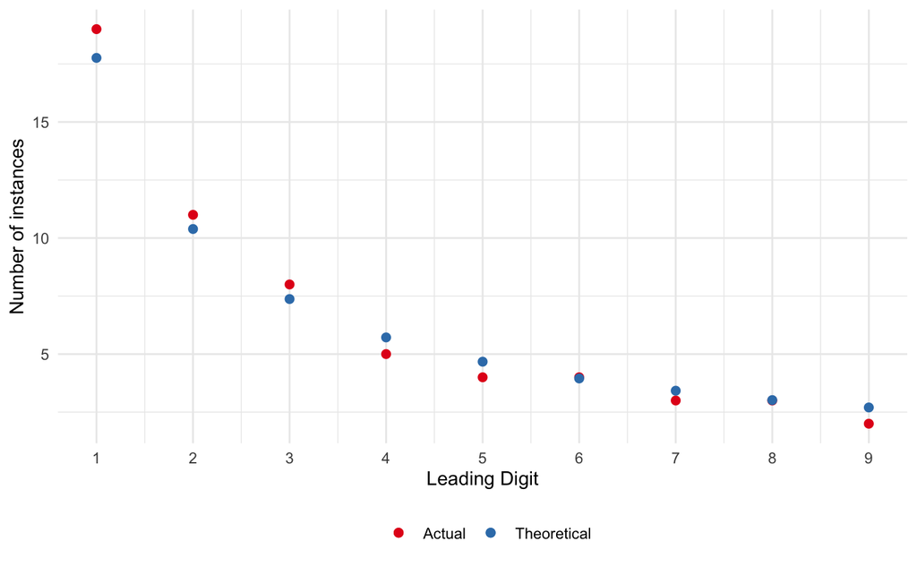

```r
covidindia %>%
  count(Date) %>%
  mutate(
    Total=cumsum(n),
    Lead=as.numeric(str_sub(as.character(Total), 1,1))
  ) %>%
  count(Lead) %>%
  mutate(
    Theoretical=sum(n) * log10(1 + 1/Lead)
  ) %>%
  ggplot(aes(x=Lead, y=n, col='Actual')) + geom_point(size=2) + geom_point(aes(y=Theoretical, col='Theoretical'),size=2) + scale_color_brewer(palette='Set1') + theme_minimal() + scale_x_continuous("Leading Digit", breaks=1:9) + scale_y_continuous("Number of instances") + theme(legend.position = 'bottom', legend.title = element_blank())
```

Let’s do the same thing by state

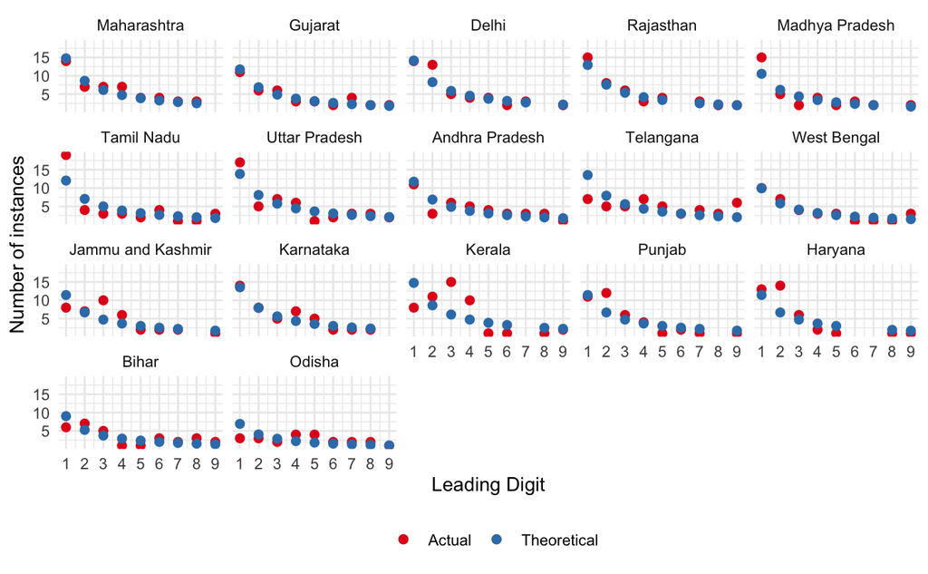

```r
covidindia %>%
  rename(State=detectedstate) %>%
  count(Date, State) %>%
  filter(!is.na(Date)) %>%
  group_by(State) %>%
  arrange(Date) %>%
  mutate(Cumul=cumsum(n),Total=sum(n)) %>%
  filter(Total >= 100) %>%
  mutate(
    Lead=as.numeric(str_sub(as.character(Cumul), 1,1))
  ) %>%
  count(State, Lead, Total) %>%
  group_by(State) %>%
  mutate(
    Theoretical=sum(n) * log10(1 + 1/Lead)
  ) %>%
  ggplot(aes(x=Lead, y=n, col='Actual')) + geom_point(size=2) + geom_point(aes(y=Theoretical, col='Theoretical'),size=2) + scale_color_brewer(palette='Set1') + theme_minimal() + scale_x_continuous("Leading Digit", breaks=1:9) + scale_y_continuous("Number of instances") + theme(legend.position = 'bottom', legend.title = element_blank()) + facet_wrap(~reorder(State, -Total))
```

Let’s just look at the Karnataka districts

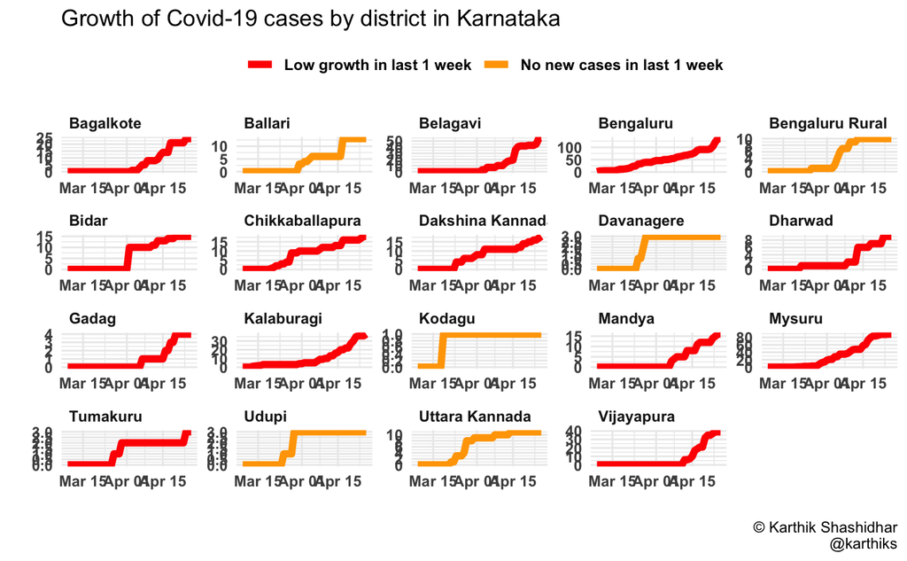

```r
covidindia %>%
  filter(!is.na(Date)) %>%
  rename(State=detectedstate, District=detecteddistrict) %>%
  filter(State=="Karnataka") %>%
  count(District, Date) %>%
  complete(District, Date, fill = list(n=0)) %>%
  arrange(District, Date) %>%
  group_by(District) %>%
  mutate(
    Total=cumsum(n),
    Latest=Total[Date==max(Date)],
    Back1week=Total[Date==(max(Date)-7)],
    Back3days=Total[Date==(max(Date)-3)],
    WeekGrowth=Latest/Back1week-1,
    Growth3=Latest/Back3days-1,
    colour=ifelse(Latest==Back1week, 'No new cases in last 1 week', ifelse((Back1week==0 & Latest > 0) | WeekGrowth > 1 | Growth3 > 0.7, 'Doubled in 1 week OR 70% growth in last 3 days', 'Low growth in last 1 week'))
  ) %>%
  ggplot(aes(x=Date, y=Total, col=colour)) + geom_line(lwd=2) + facet_wrap(~District, scales='free') + theme_minimal() + scale_y_continuous('', breaks= scales::pretty_breaks()) + scale_x_date('') + scale_colour_manual(values = c('red', 'orange', 'yellow')) + theme(strip.text = element_text(face='bold', hjust=0), legend.position = 'top', legend.title = element_blank(), legend.text = element_text(face='bold'), axis.text = element_text(face='bold')) + labs(title="Growth of Covid-19 cases by district in Karnataka", caption='© Karthik Shashidhar\n  @karthiks')
```

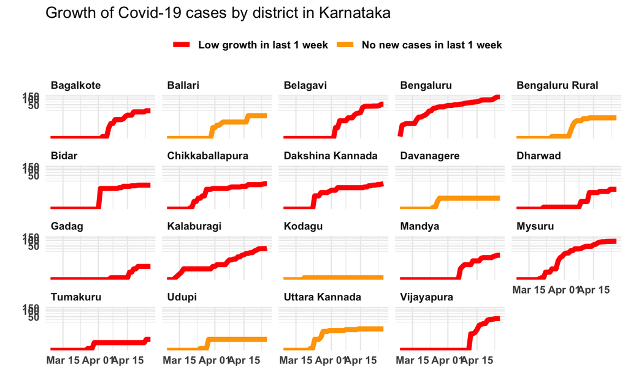

```r
covidindia %>%
  filter(!is.na(Date)) %>%
  rename(State=detectedstate, District=detecteddistrict) %>%
  filter(State=="Karnataka") %>%
  count(District, Date) %>%
  complete(District, Date, fill = list(n=0)) %>%
  arrange(District, Date) %>%
  group_by(District) %>%
  mutate(
    Total=cumsum(n),
    Latest=Total[Date==max(Date)],
    Back1week=Total[Date==(max(Date)-7)],
    Back3days=Total[Date==(max(Date)-3)],
    WeekGrowth=Latest/Back1week-1,
    Growth3=Latest/Back3days-1,
    colour=ifelse(Latest==Back1week, 'No new cases in last 1 week', ifelse((Back1week==0 & Latest > 0) | WeekGrowth > 1 | Growth3 > 0.7, 'Doubled in 1 week OR 70% growth in last 3 days', 'Low growth in last 1 week'))
  ) %>%
  ggplot(aes(x=Date, y=Total, col=colour)) + geom_line(lwd=2) + facet_wrap(~District, scales='fixed') + theme_minimal() + scale_y_log10('', breaks= scales::pretty_breaks()) + scale_x_date('') + scale_colour_manual(values = c('red', 'orange', 'yellow')) + theme(strip.text = element_text(face='bold', hjust=0), legend.position = 'top', legend.title = element_blank(), legend.text = element_text(face='bold'), axis.text = element_text(face='bold')) + ggtitle("Growth of Covid-19 cases by district in Karnataka")
```

Do it on a choropleth

```r
require(sf)
kar <- st_read('~/Documents/work/data work/maps/maps/Districts/Census_2011/2011_Dist.shp') %>%
  filter(ST_NM=='Karnataka')
```

[output not shown]

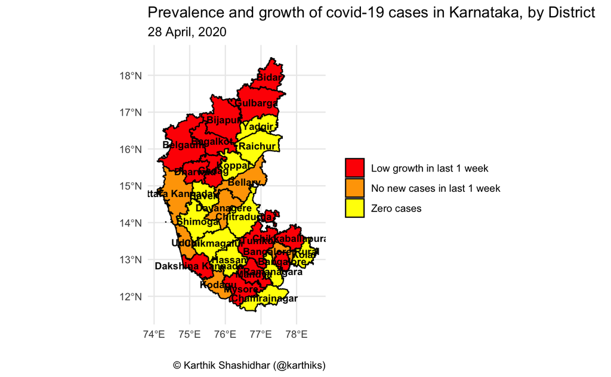

```r
kar %>%
  mutate(DISTRICT=as.character(DISTRICT)) %>%
  left_join(
    covidindia %>%
      rename(State=detectedstate, District=detecteddistrict) %>%
      filter(State=="Karnataka" & !is.na(Date)) %>%
      count(District, Date) %>%
      complete(District, Date, fill = list(n=0)) %>%
      arrange(District, Date) %>%
      group_by(District) %>%
      mutate(
        Total=cumsum(n),
        Latest=Total[Date==max(Date)],
        Back1week=Total[Date==(max(Date)-7)],
        Back3days=Total[Date==(max(Date)-3)],
        WeekGrowth=Latest/Back1week-1,
        Growth3=Latest/Back3days-1,
        colour=ifelse(Latest==Back1week, 'No new cases in last 1 week', ifelse((Back1week==0 & Latest > 0) | WeekGrowth > 1 | Growth3 > 0.7, 'Doubled in 1 week OR 70% growth in last 3 days', 'Low growth in last 1 week'))
      ) %>%
      distinct(District, colour) %>%
      left_join(
        tibble(
          District=c('Bagalkote', 'Ballari', 'Belagavi', 'Bengaluru', "Bengaluru Rural", "Kalaburagi", 'Mysuru', 'Tumakuru', 'Vijayapura'),
          DISTRICT=c('Bagalkot', 'Bellary', 'Belgaum', 'Bangalore', 'Bangalore Rural', 'Gulbarga', 'Mysore', 'Tumkur' , 'Bijapur')
        ),
        by='District'
      ) %>%
      mutate(DISTRICT=coalesce(DISTRICT, District)) %>%
      ungroup() %>%
      distinct(DISTRICT, colour),
    by='DISTRICT'
  ) %>%
  mutate(colour=coalesce(colour, 'Zero cases')) %>%
  ggplot() + geom_sf(aes(fill=colour), col='black') + geom_text(data=st_coordinates(st_centroid(kar)) %>% as_tibble() %>% mutate(DISTRICT=kar$DISTRICT), aes(x=X, y=Y, label=DISTRICT), fontface='bold', size=3)+  scale_fill_manual(values = c('red', 'orange', 'yellow', 'darkgreen'))+ theme_minimal() + theme(legend.position = 'right', legend.title = element_blank()) + labs(title="Prevalence and growth of covid-19 cases in Karnataka, by District", subtitle = format(Sys.Date(), '%d %B, %Y'), caption="© Karthik Shashidhar (@karthiks)") + xlab('') + ylab('')
```

```r
read_csv('https://api.covid19india.org/csv/latest/statewise_tested_numbers_data.csv') %>%
  mutate(
    Date=as.Date(`Updated On`, '%d/%m/%Y'),
    Tested=as.numeric(`Total Tested`)
  ) %>%
  rename(state=State) ->
  covidtests
```

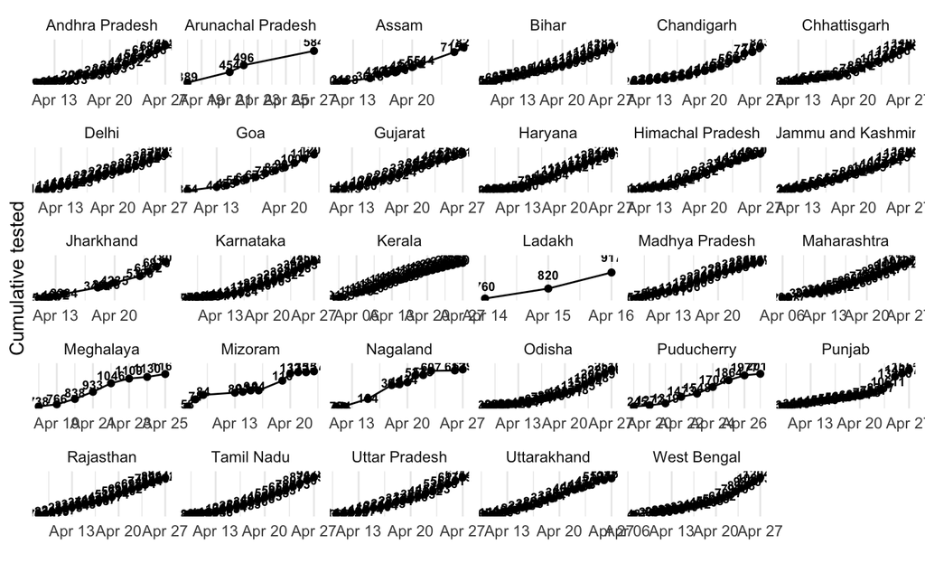

```r
covidtests %>%
  distinct(state, Date, Tested) %>%
  filter(!is.na(Tested)) %>%
  group_by(state) %>%
  arrange(state, Date) %>%
  mutate(
    TestedToday=Tested-lag(Tested, 1),
    DateDiff=as.numeric(Date-lag(Date, 1), units='days')
  ) %>%
  filter(n() > 5 & !is.na(DateDiff) & DateDiff==1) %>%
  ggplot(aes(x=Date, y=Tested, label=Tested)) + geom_point() + geom_line() + geom_text(aes(y=1.1*Tested), fontface='bold', size=2.5) + theme_minimal() + facet_wrap(~state, scales='free') + xlab('') + scale_y_continuous("Cumulative tested", breaks=c())
```

```r
covidtests %>%
  distinct(state, Date, Tested) %>%
  filter(!is.na(Tested)) %>%
  group_by(state) %>%
  arrange(state, Date) %>%
  mutate(
    TestedToday=Tested-lag(Tested, 1),
    DateDiff=as.numeric(Date-lag(Date, 1), units='days')
  ) %>%
  filter(n() > 5 & !is.na(DateDiff) & DateDiff==1 & state=='Karnataka')
```

| state | Date | Tested | TestedToday | DateDiff |
| --- | --- | --- | --- | --- |
| Karnataka | 2020-04-08 | 6967 | 387 | 1 |
| Karnataka | 2020-04-09 | 7613 | 646 | 1 |
| Karnataka | 2020-04-10 | 7975 | 362 | 1 |
| Karnataka | 2020-04-11 | 8560 | 585 | 1 |
| Karnataka | 2020-04-12 | 9251 | 691 | 1 |
| Karnataka | 2020-04-13 | 10017 | 766 | 1 |
| Karnataka | 2020-04-14 | 11107 | 1090 | 1 |
| Karnataka | 2020-04-15 | 12483 | 1376 | 1 |
| Karnataka | 2020-04-16 | 13724 | 1241 | 1 |
| Karnataka | 2020-04-17 | 17594 | 3870 | 1 |

[output cut: 10 more lines]

Let’s plot testing as well as positive cases

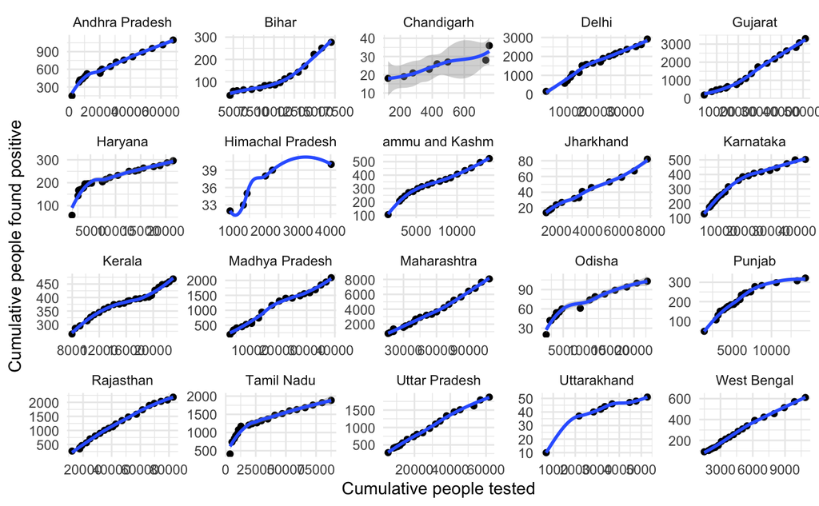

```r
covidtests %>%
  distinct(state, Date, Tested) %>%
  inner_join(
    covidindia %>%
      count(Date, state=detectedstate, name = 'Positive') %>%
      arrange(state, Date) %>%
      group_by(state) %>%
      mutate(Positive=cumsum(Positive)),
    by=c("Date", "state")
  ) %>%
  filter(complete.cases(.)) %>%
  group_by(state) %>%
  filter(n() > 5) %>%
  ggplot(aes(x=Tested, y=Positive, label=format(Date, '%d-%m'))) + geom_point() + geom_smooth(method='loess', formula='y~x') + facet_wrap(~state, scales='free') + theme_minimal()  + xlab("Cumulative people tested") + ylab("Cumulative people found positive")
```

[output not shown]

[output cut: 493 more lines]

```r
cv2 <- read_csv('https://api.covid19india.org/csv/latest/raw_data.csv')
```

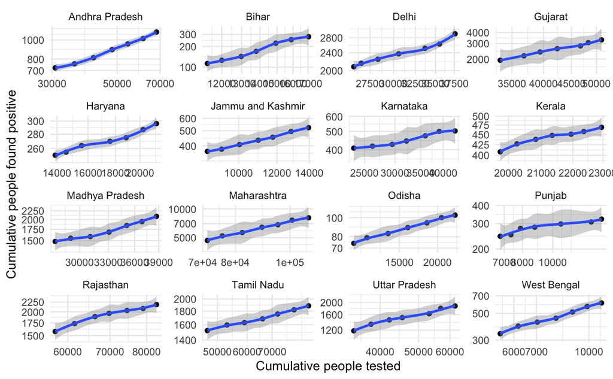

```r
covidtests %>%
  distinct(state, Date, Tested) %>%
  inner_join(
    covidindia %>%
      count(Date, state=detectedstate, name = 'Positive') %>%
      arrange(state, Date) %>%
      group_by(state) %>%
      mutate(Positive=cumsum(Positive)),
    by=c("Date", "state")
  ) %>%
  filter(complete.cases(.)) %>%
  group_by(state) %>%
  filter(Date >= (max(Date)-6)) %>%
  filter(n() >= 6) %>%
  ggplot(aes(x=Tested, y=Positive, label=format(Date, '%d-%m'))) + geom_point() + geom_smooth(method='loess', formula='y~x') + facet_wrap(~state, scales='free') + theme_minimal()  + scale_x_log10("Cumulative people tested") + scale_y_log10("Cumulative people found positive")
```

State-wise coloured graph

```r
covidtests %>%
  distinct(state, Date, Tested) %>%
  arrange(state, Date) %>%
  filter(!is.na(Tested)) %>%
  group_by(state) %>%
  mutate(
    NewTests=Tested-lag(Tested, 1)
  ) %>%
  filter(!is.na(NewTests) & NewTests > 0) %>%
  mutate(
    DateDiff=as.numeric(Date-lag(Date,1))
  ) %>%
  filter(DateDiff==1) %>%
  filter(n() >= 5) %>%
  inner_join(
    covidindia %>%
      count(Date, state=detectedstate, name = 'Positive') %>%
      arrange(state, Date) %>%
      group_by(state) %>%
      mutate(Positive=cumsum(Positive)),
    by=c("Date", "state")
  ) %>%
  ungroup() %>%
  filter(complete.cases(.)) %>%
  group_by(state) %>%
  arrange(state,Date) %>%
  mutate(
    TestGrowth=log(Tested/lag(Tested,3))/3,
    CaseGrowth=log(Positive/lag(Positive,3))/3,
    Slope=CaseGrowth/TestGrowth,
    LastBig=as.numeric(Sys.Date()-max(Date[!is.na(Slope) & Slope >= 0.5]))
  ) %>%
  distinct(state, LastBig) %>%
  ungroup() %>%
  mutate(
    LastBig=ifelse(LastBig==Inf,NA,LastBig),
    LastBig=coalesce(LastBig, max(LastBig, na.rm=T)),
    BlueNess=(LastBig-min(LastBig))/(max(LastBig)-min(LastBig)),
    Colour=rgb(1,0.4+BlueNess*0.6,0.4-BlueNess*0.4)
  )%>%
  distinct(state, Colour) ->
  stateColours
```

[output not shown]

```r
covidtests %>%
  distinct(state, Date, Tested) %>%
  inner_join(
    covidindia %>%
      count(Date, state=detectedstate, name = 'Positive') %>%
      arrange(state, Date) %>%
      group_by(state) %>%
      mutate(Positive=cumsum(Positive)),
    by=c("Date", "state")
  ) %>%
  filter(complete.cases(.)) %>%
  group_by(state) %>%
  filter(n() > 5) ->
  stateTestCases
stateColours %>%
  filter(state %in% stateTestCases$state) ->
  stateColours
stateGraphs <- list()
for(i in 1:nrow(stateColours)) {
  stateTestCases %>%
    filter(state==stateColours$state[i]) %>%
    ggplot(aes(x=Tested, y=Positive, label=format(Date, '%d-%m'))) + geom_point() + geom_smooth(method='loess', formula='y~x') + theme_minimal()  + scale_x_continuous("Total tests", labels=scales::label_number_si()) + scale_y_continuous("Total Positive Cases") + ggtitle(stateColours$state[i]) + theme(plot.background = element_rect(fill=stateColours$Colour[i]), title=element_text(face='bold', size=16), text=element_text(face='bold', size=10)) ->
    stateGraphs[[i]]
}
require(patchwork)
stateGraphs %>% wrap_plots(nrow=3, guides = 'collect') ->
  p
ggsave('tmp.png', p, width=20, height=10, units='in')
```

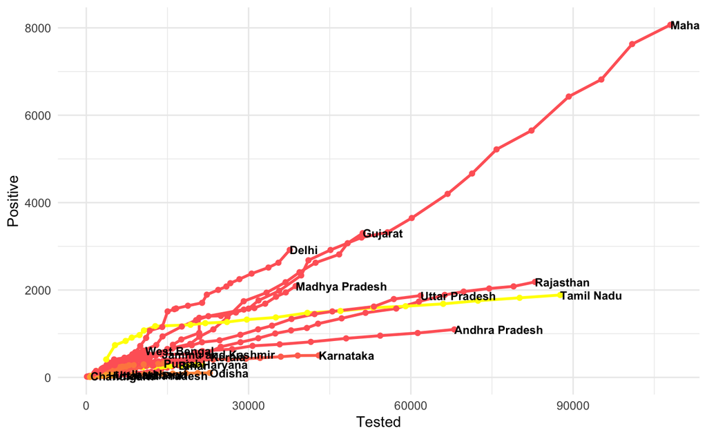

```r
stateTestCases %>%
  group_by(state) %>%
  mutate(Label=ifelse(Date==max(Date), state, '')) %>%
  inner_join(stateColours, by='state') %>%
  ggplot(aes(x=Tested, y=Positive, group=state, col=Colour, label=Label)) + geom_line(lwd=1) + geom_point() + geom_text(nudge_x=10,fontface='bold', col='black', size=3, hjust=0)+ scale_colour_identity() + theme_minimal()
```

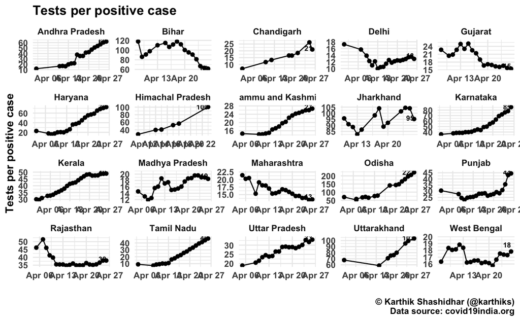

```r
stateTestCases %>%
  group_by(state) %>%
  mutate(
    Ratio=Tested/Positive,
    Label=ifelse(Date==max(Date), round(Ratio), '')
  ) %>%
  ggplot(aes(x=Date, y=Ratio, label=Label)) + geom_point() + geom_line() + geom_text(hjust=1, nudge_y=1, fontface='bold', size=2.5) + facet_wrap(~state, scales='free') + theme_minimal() + xlab('') + ylab("Tests per positive case")+ labs(title="Tests per positive case", caption="© Karthik Shashidhar (@karthiks)\n Data source: covid19india.org" ) + theme(title=element_text(face='bold'), text=element_text(face='bold'))
```

```r
covidtests %>%
  group_by(Date) %>%
  summarise(Tests=sum(Tested, na.rm=T)) %>%
  inner_join(
    covidindia %>%
      count(Date) %>%
      mutate(Positives=cumsum(n)),
    by='Date'
  ) %>%
  arrange(Date)
```

| Date | Tests | n | Positives |
| --- | --- | --- | --- |
| 2020-04-01 | 11245 | 424 | 2059 |
| 2020-04-02 | 14906 | 486 | 2545 |
| 2020-04-03 | 20130 | 560 | 3105 |
| 2020-04-04 | 1042 | 579 | 3684 |
| 2020-04-05 | 59455 | 609 | 4293 |
| 2020-04-06 | 29698 | 485 | 4778 |
| 2020-04-07 | 79123 | 573 | 5351 |
| 2020-04-08 | 63058 | 565 | 5916 |
| 2020-04-09 | 122239 | 813 | 6729 |
| 2020-04-10 | 155566 | 871 | 7600 |

[output cut: 16 more lines]

```r
520000/23000
```

```
[1] 22.6087
```

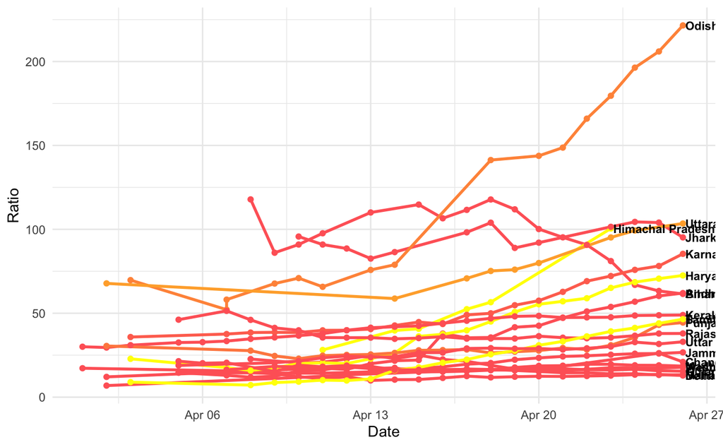

```r
stateTestCases %>%
  group_by(state) %>%
  mutate(
    Label=ifelse(Date==max(Date), state, ''),
    Ratio=Tested/Positive
  ) %>%
  inner_join(stateColours, by='state') %>%
  ggplot(aes(x=Date, y=Ratio, group=state, col=Colour, label=Label)) + geom_line(lwd=1) + geom_point() + geom_text(nudge_x=0.1,fontface='bold', col='black', size=3, hjust=0)+ scale_colour_identity() + theme_minimal()
```

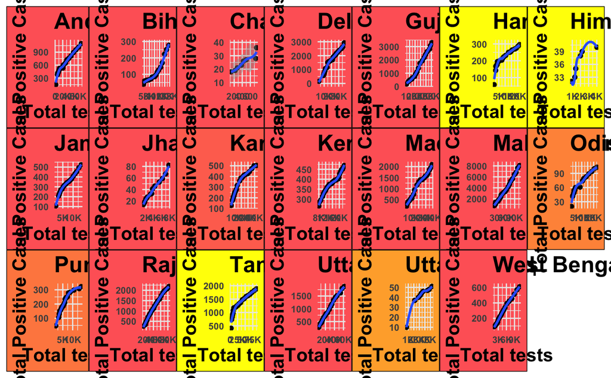

```r
p
```